# **Interpretation of the Plots**

## **Short-Term Consumption Trends:**

Focusing on specific periods (e.g., January–February 2017), we can see smaller trends within the broader time series. Daily fluctuations in energy usage can be observed more clearly when zooming in on specific months.

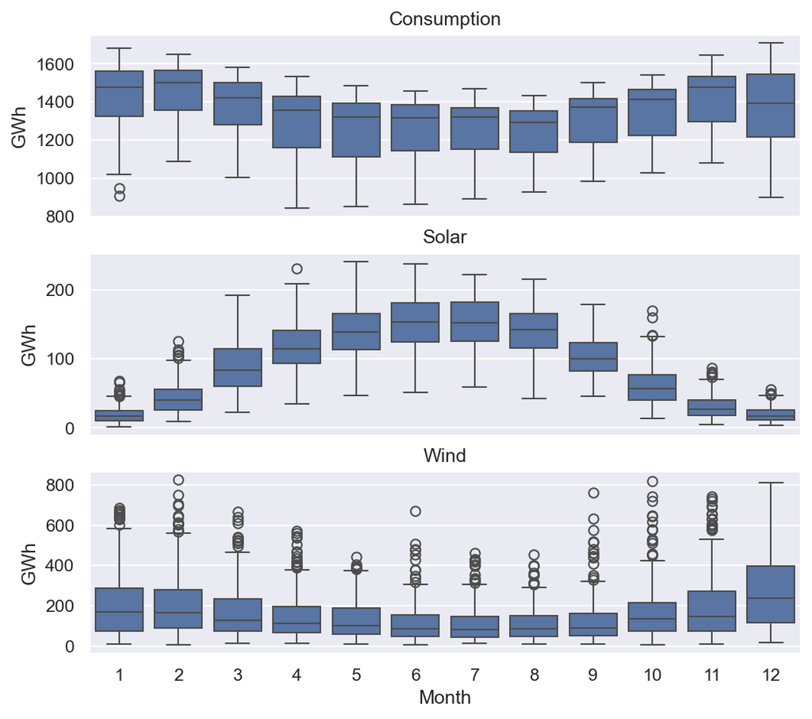

```python
fig, axes = plt.subplots(3, 1, figsize=(8, 7), sharex=True)
for name, ax in zip(['Consumption', 'Solar', 'Wind'], axes):
    sns.boxplot(data=df_power, x='Month', y=name, ax=ax)
    ax.set_ylabel('GWh')
    ax.set_title(name)
    if ax != axes[-1]:
        ax.set_xlabel('')
```

## **Comparison of Energy Sources (Wind, Solar, and Total Consumption):**

The separate plots for wind and solar energy production indicate that renewable energy sources contribute significantly but are highly variable. Solar production follows a strong seasonal pattern, peaking in summer, while wind energy shows more irregular fluctuations.

[figure not shown]

```python
sns.boxplot(data=df_power, x='Weekday Name', y='Consumption')
```

```python
columns = ['Consumption', 'Wind', 'Solar', 'Wind+Solar']
power_weekly_mean = df_power[columns].resample('W').mean()
power_weekly_mean.head(10)
```

| Date | Consumption | Wind | Solar | Wind+Solar |
| --- | --- | --- | --- | --- |
| 2006-01-01 | 1069.184000 | NaN | NaN | NaN |
| 2006-01-08 | 1381.300143 | NaN | NaN | NaN |
| 2006-01-15 | 1486.730286 | NaN | NaN | NaN |
| 2006-01-22 | 1490.031143 | NaN | NaN | NaN |
| 2006-01-29 | 1514.176857 | NaN | NaN | NaN |
| 2006-02-05 | 1501.403286 | NaN | NaN | NaN |
| 2006-02-12 | 1498.217143 | NaN | NaN | NaN |
| 2006-02-19 | 1446.507429 | NaN | NaN | NaN |
| 2006-02-26 | 1447.651429 | NaN | NaN | NaN |
| 2006-03-05 | 1439.727857 | NaN | NaN | NaN |

```python
start, end = '2016-01', '2016-06'
```

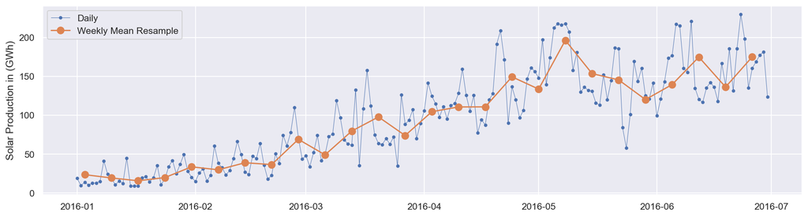

```python
fig, ax = plt.subplots()

ax.plot(df_power.loc[start:end, 'Solar'],
marker='.', linestyle='-', linewidth=0.5, label='Daily')
ax.plot(power_weekly_mean.loc[start:end, 'Solar'],
marker='o', markersize=8, linestyle='-', label='Weekly Mean Resample')
ax.set_ylabel('Solar Production in (GWh)')
ax.legend()
```

## **Time Series Analysis: Bitcoin Dataset**

```python
df_bit = pd.read_csv('btc-eth-prices.csv')
df_bit.head()
```

|  | Timestamp | Bitcoin | Ether |
| --- | --- | --- | --- |
| 0 | 2017-04-02 | 1099.169125 | 48.55 |
| 1 | 2017-04-03 | 1141.813000 | 44.13 |
| 2 | 2017-04-04 | 1141.600363 | 44.43 |
| 3 | 2017-04-05 | 1133.079314 | 44.90 |
| 4 | 2017-04-06 | 1196.307937 | 43.23 |

```python
df_bit.dtypes
```

```
Timestamp     object
Bitcoin      float64
Ether        float64
dtype: object
```

```python
df_bit.isna().sum()
```

```
Timestamp    0
Bitcoin      0
Ether        3
dtype: int64
```

```python
df_bit['Ether'] = df_bit['Ether'].fillna(df_bit['Ether'].mean())
```

```python
df_bit.isna().sum()
```

```
Timestamp    0
Bitcoin      0
Ether        0
dtype: int64
```

```python
df_bit['Timestamp'] = pd.to_datetime(df_bit['Timestamp'])
df_bit.head()
```

|  | Timestamp | Bitcoin | Ether |
| --- | --- | --- | --- |
| 0 | 2017-04-02 | 1099.169125 | 48.55 |
| 1 | 2017-04-03 | 1141.813000 | 44.13 |
| 2 | 2017-04-04 | 1141.600363 | 44.43 |
| 3 | 2017-04-05 | 1133.079314 | 44.90 |
| 4 | 2017-04-06 | 1196.307937 | 43.23 |

```python
df_bit.dtypes
```

```
Timestamp    datetime64[ns]
Bitcoin             float64
Ether               float64
dtype: object
```

```python
df_bit = df_bit.set_index('Timestamp')
df_bit.tail(3)
```

| Timestamp | Bitcoin | Ether |
| --- | --- | --- |
| 2018-03-30 | 6882.531667 | 393.82 |
| 2018-03-31 | 6935.480000 | 394.07 |
| 2018-04-01 | 6794.105000 | 378.85 |

```python
df_bit.index
```

```
DatetimeIndex(['2017-04-02', '2017-04-03', '2017-04-04', '2017-04-05',
               '2017-04-06', '2017-04-07', '2017-04-08', '2017-04-09',
               '2017-04-10', '2017-04-11',
               ...
               '2018-03-23', '2018-03-24', '2018-03-25', '2018-03-26',
               '2018-03-27', '2018-03-28', '2018-03-29', '2018-03-30',
               '2018-03-31', '2018-04-01'],
              dtype='datetime64[ns]', name='Timestamp', length=365, freq=None)
```

```python
df_bit.dtypes
```

```
Bitcoin    float64
Ether      float64
dtype: object
```

```python
df_bit['Year'] = df_bit.index.year
df_bit['Month'] = df_bit.index.month
df_bit['Weekday Name'] = df_bit.index.day_name
```

```python
df_bit.sample(5, random_state=0)
```

| Timestamp | Bitcoin | Ether | Year | Month | Weekday Name |
| --- | --- | --- | --- | --- | --- |
| 2017-07-17 | 2176.623488 | 189.97 | 2017 | 7 | <bound method _inherit_from_data.<locals>.meth... |
| 2017-12-17 | 19289.785000 | 717.71 | 2017 | 12 | <bound method _inherit_from_data.<locals>.meth... |
| 2017-05-17 | 1807.485062 | 86.98 | 2017 | 5 | <bound method _inherit_from_data.<locals>.meth... |
| 2017-04-28 | 1331.294429 | 72.42 | 2017 | 4 | <bound method _inherit_from_data.<locals>.meth... |
| 2017-06-19 | 2617.210263 | 358.20 | 2017 | 6 | <bound method _inherit_from_data.<locals>.meth... |

```python
df_bit.loc['2017-04-28']
```

```
Bitcoin                                               1331.294429
Ether                                                       72.42
Year                                                         2017
Month                                                           4
Weekday Name    <bound method _inherit_from_data.<locals>.meth...
Name: 2017-04-28 00:00:00, dtype: object
```

```python
df_bit.loc['2017-01-01':'2017-12-30']
```

| Timestamp | Bitcoin | Ether | Year | Month | Weekday Name |
| --- | --- | --- | --- | --- | --- |
| 2017-04-02 | 1099.169125 | 48.55 | 2017 | 4 | <bound method _inherit_from_data.<locals>.meth... |
| 2017-04-03 | 1141.813000 | 44.13 | 2017 | 4 | <bound method _inherit_from_data.<locals>.meth... |
| 2017-04-04 | 1141.600363 | 44.43 | 2017 | 4 | <bound method _inherit_from_data.<locals>.meth... |
| 2017-04-05 | 1133.079314 | 44.90 | 2017 | 4 | <bound method _inherit_from_data.<locals>.meth... |
| 2017-04-06 | 1196.307937 | 43.23 | 2017 | 4 | <bound method _inherit_from_data.<locals>.meth... |
| ... | ... | ... | ... | ... | ... |
| 2017-12-26 | 15999.048333 | 753.40 | 2017 | 12 | <bound method _inherit_from_data.<locals>.meth... |
| 2017-12-27 | 15589.321667 | 739.94 | 2017 | 12 | <bound method _inherit_from_data.<locals>.meth... |
| 2017-12-28 | 14380.581667 | 716.69 | 2017 | 12 | <bound method _inherit_from_data.<locals>.meth... |
| 2017-12-29 | 14640.140000 | 739.60 | 2017 | 12 | <bound method _inherit_from_data.<locals>.meth... |
| 2017-12-30 | 13215.574000 | 692.99 | 2017 | 12 | <bound method _inherit_from_data.<locals>.meth... |

273 rows × 5 columns

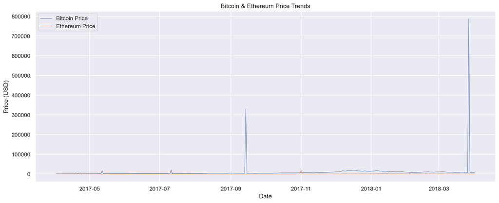

```python
plt.figure(figsize=(16, 6))
plt.plot(df_bit.index, df_bit['Bitcoin'], label="Bitcoin Price", linewidth=0.7)
plt.plot(df_bit.index, df_bit['Ether'], label="Ethereum Price", linewidth=0.7)
plt.xlabel("Date")
plt.ylabel("Price (USD)")
plt.title("Bitcoin & Ethereum Price Trends")
plt.legend()
plt.show()
```